# SI 618 Homework #4

## Taylor Swift songs

Last updated 2024-13-02

The dataset for this assignment is from https://www.kaggle.com/datasets/jarredpriester/taylor-swift-spotify-dataset/data.

**NOTE**: Use the dataset from Canvas rather than the dataset from Kaggle, which is updated frequently and may change while you are completing this assignment.

This dataset consist of data from Spotify's API on all albums listed on Spotify for Taylor Swift. I set up the dataset to update monthly so that if any albums get added it will get added to the dataset too. At first it may look like there are song duplicates but I checked and all song IDs are unique.

The columns in this dataset are:

name - the name of the song

album - the name of the album

release_date - the day month and year the album was released

track number - the order the song appears on the album

id - the Spotify id for the song

uri - the Spotify uri for the song

acousticness - A confidence measure from 0.0 to 1.0 of whether the track is acoustic. 1.0 represents high confidence the track is acoustic.

danceability - Danceability describes how suitable a track is for dancing based on a combination of musical elements including tempo, rhythm stability, beat strength, and overall regularity. A value of 0.0 is least danceable and 1.0 is most danceable.

energy - Energy is a measure from 0.0 to 1.0 and represents a perceptual measure of intensity and activity. Typically, energetic tracks feel fast, loud, and noisy. For example, death metal has high energy, while a Bach prelude scores low on the scale. Perceptual features contributing to this attribute include dynamic range, perceived loudness, timbre, onset rate, and general entropy.

instrumentalness - Predicts whether a track contains no vocals. "Ooh" and "aah" sounds are treated as instrumental in this context. Rap or spoken word tracks are clearly "vocal". The closer the instrumentalness value is to 1.0, the greater likelihood the track contains no vocal content. Values above 0.5 are intended to represent instrumental tracks, but confidence is higher as the value approaches 1.0.

liveness - Detects the presence of an audience in the recording. Higher liveness values represent an increased probability that the track was performed live. A value above 0.8 provides strong likelihood that the track is live.

loudness - The overall loudness of a track in decibels (dB). Loudness values are averaged across the entire track and are useful for comparing relative loudness of tracks. Loudness is the quality of a sound that is the primary psychological correlate of physical strength (amplitude). Values typically range between -60 and 0 db.

speechiness - detects the presence of spoken words in a track. The more exclusively speech-like the recording (e.g. talk show, audio book, poetry), the closer to 1.0 the attribute value. Values above 0.66 describe tracks that are probably made entirely of spoken words. Values between 0.33 and 0.66 describe tracks that may contain both music and speech, either in sections or layered, including such cases as rap music. Values below 0.33 most likely represent music and other non-speech-like tracks.

tempo - The overall estimated tempo of a track in beats per minute (BPM). In musical terminology, tempo is the speed or pace of a given piece and derives directly from the average beat duration.

valence - A measure from 0.0 to 1.0 describing the musical positiveness conveyed by a track. Tracks with high valence sound more positive (e.g. happy, cheerful, euphoric), while tracks with low valence sound more negative (e.g. sad, depressed, angry).

popularity - the popularity of the song from 0 to 100

duration_ms - The duration of the track in milliseconds.

We are going to refer to the tracks' properties of danceability, energy, instrumentalness, liveness, loudness, speechiness, tempo, and valence as "features" of the tracks.

Points will be allocated according to the following rubric:

- 90-100%: Question is correctly and completely answered. Answer consists of well-written code that conforms to [PEP 8](https://www.python.org/dev/peps/pep-0008/) guidelines and is accompanied by a written interpretation in a Markdown block. Written interpretation does not contain spelling, grammar or stylistic errors (see [Strunk & White](https://drive.google.com/file/d/1L0P7xJwjUGBvyb49mL3dw1Bt7hzRTiTl/view?usp=sharing) for a detailed specifications). Minor problems, such as formatting, incorrect submissions, missing names, etc. will result in less than 100%.
- 75-85% : Answer is mostly complete and correct; two or fewer noticeable omissions or errors. Minor stylistic flaws, either in code or in written interpretation.
- 50-70%: Answer has significant omissions or errors; Noticeable departure from PEP-8 guildelines and/or moderate spelling, grammar, or style issues in written interpretations.
- 25-45%: Question is perfunctorily attempted. Substantial parts are missing or incorrect.
- 0 points: Question not attempted.

Be sure to include interpretations of your results for each question.

```python
import pandas as pd
import seaborn as sns
import numpy as np
import matplotlib.pyplot as plt
import re
```

```python
ts_spotify = pd.read_csv("/Users/an/Documents/Umich/SI 618/618_HW/taylor_swift_spotify.csv")
ts_spotify
```

|  | Unnamed: 0 | name | album | release_date | track_number | id | uri | acousticness | danceability | energy | instrumentalness | liveness | loudness | speechiness | tempo | valence | popularity | duration_ms |
| --- | --- | --- | --- | --- | --- | --- | --- | --- | --- | --- | --- | --- | --- | --- | --- | --- | --- | --- |
| 0 | 0 | Welcome To New York (Taylor's Version) | 1989 (Taylor's Version) [Deluxe] | 2023-10-27 | 1 | 4WUepByoeqcedHoYhSNHRt | spotify:track:4WUepByoeqcedHoYhSNHRt | 0.009420 | 0.757 | 0.610 | 0.000037 | 0.3670 | -4.840 | 0.0327 | 116.998 | 0.685 | 71 | 212600 |
| 1 | 1 | Blank Space (Taylor's Version) | 1989 (Taylor's Version) [Deluxe] | 2023-10-27 | 2 | 0108kcWLnn2HlH2kedi1gn | spotify:track:0108kcWLnn2HlH2kedi1gn | 0.088500 | 0.733 | 0.733 | 0.000000 | 0.1680 | -5.376 | 0.0670 | 96.057 | 0.701 | 72 | 231833 |
| 2 | 2 | Style (Taylor's Version) | 1989 (Taylor's Version) [Deluxe] | 2023-10-27 | 3 | 3Vpk1hfMAQme8VJ0SNRSkd | spotify:track:3Vpk1hfMAQme8VJ0SNRSkd | 0.000421 | 0.511 | 0.822 | 0.019700 | 0.0899 | -4.785 | 0.0397 | 94.868 | 0.305 | 74 | 231000 |
| 3 | 3 | Out Of The Woods (Taylor's Version) | 1989 (Taylor's Version) [Deluxe] | 2023-10-27 | 4 | 1OcSfkeCg9hRC2sFKB4IMJ | spotify:track:1OcSfkeCg9hRC2sFKB4IMJ | 0.000537 | 0.545 | 0.885 | 0.000056 | 0.3850 | -5.968 | 0.0447 | 92.021 | 0.206 | 72 | 235800 |
| 4 | 4 | All You Had To Do Was Stay (Taylor's Version) | 1989 (Taylor's Version) [Deluxe] | 2023-10-27 | 5 | 2k0ZEeAqzvYMcx9Qt5aClQ | spotify:track:2k0ZEeAqzvYMcx9Qt5aClQ | 0.000656 | 0.588 | 0.721 | 0.000000 | 0.1310 | -5.579 | 0.0317 | 96.997 | 0.520 | 71 | 193289 |
| ... | ... | ... | ... | ... | ... | ... | ... | ... | ... | ... | ... | ... | ... | ... | ... | ... | ... | ... |
| 525 | 525 | Our Song | Taylor Swift | 2006-10-24 | 11 | 15DeqWWQB4dcEWzJg15VrN | spotify:track:15DeqWWQB4dcEWzJg15VrN | 0.111000 | 0.668 | 0.672 | 0.000000 | 0.3290 | -4.931 | 0.0303 | 89.011 | 0.539 | 76 | 201106 |
| 526 | 526 | I'm Only Me When I'm With You | Taylor Swift | 2006-10-24 | 12 | 0JIdBrXGSJXS72zjF9ss9u | spotify:track:0JIdBrXGSJXS72zjF9ss9u | 0.004520 | 0.563 | 0.934 | 0.000807 | 0.1030 | -3.629 | 0.0646 | 143.964 | 0.518 | 61 | 213053 |
| 527 | 527 | Invisible | Taylor Swift | 2006-10-24 | 13 | 5OOd01o2YS1QFwdpVLds3r | spotify:track:5OOd01o2YS1QFwdpVLds3r | 0.637000 | 0.612 | 0.394 | 0.000000 | 0.1470 | -5.723 | 0.0243 | 96.001 | 0.233 | 58 | 203226 |
| 528 | 528 | A Perfectly Good Heart | Taylor Swift | 2006-10-24 | 14 | 1spLfUJxtyVyiKKTegQ2r4 | spotify:track:1spLfUJxtyVyiKKTegQ2r4 | 0.003490 | 0.483 | 0.751 | 0.000000 | 0.1280 | -5.726 | 0.0365 | 156.092 | 0.268 | 56 | 220146 |
| 529 | 529 | Teardrops on My Guitar - Pop Version | Taylor Swift | 2006-10-24 | 15 | 4pJi1rVt9GNegU9kywjg4z | spotify:track:4pJi1rVt9GNegU9kywjg4z | 0.040200 | 0.459 | 0.753 | 0.000000 | 0.0863 | -3.827 | 0.0537 | 199.997 | 0.483 | 57 | 179066 |

530 rows × 18 columns

```python
ts_spotify.isna().sum()
```

```
Unnamed: 0          0
name                0
album               0
release_date        0
track_number        0
id                  0
uri                 0
acousticness        0
danceability        0
energy              0
instrumentalness    0
liveness            0
loudness            0
speechiness         0
tempo               0
valence             0
popularity          0
duration_ms         0
dtype: int64
```

# Q1:

- Show the distribution of the popularity of the songs. Then exclude the songs that are marked as "Taylo'r version". Show the distribution of the popularity of the songs. What is the difference between the two distributions?
- (b)Show the variation in song popularity over the years. Are there any notable trends or observations? Please explain.(10)

### part (a)

the distribution of the popularity of the songs:

```
array([[<Axes: title={'center': 'popularity'}>]], dtype=object)
```

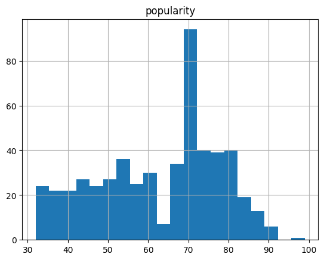

```python
ts_spotify.hist(column = 'popularity', bins = 20)
```

Then exclude the songs that are marked as "Taylo'r version". Show the distribution of the popularity of the songs.

```python
pattern = r"\b[Tt]aylor['’]s\s[Vv]ersion\b"
```

```python
p = ts_spotify.name.str.contains(pattern)
not_tversion = ts_spotify[-p]
not_tversion.head()
```

|  | Unnamed: 0 | name | album | release_date | track_number | id | uri | acousticness | danceability | energy | instrumentalness | liveness | loudness | speechiness | tempo | valence | popularity | duration_ms |
| --- | --- | --- | --- | --- | --- | --- | --- | --- | --- | --- | --- | --- | --- | --- | --- | --- | --- | --- |
| 65 | 65 | Lavender Haze | Midnights (The Til Dawn Edition) | 2023-05-26 | 1 | 24emu3sabKISjRkrys28jq | spotify:track:24emu3sabKISjRkrys28jq | 0.2360 | 0.735 | 0.454 | 0.001130 | 0.133 | -10.516 | 0.0876 | 97.043 | 0.0751 | 70 | 202395 |
| 66 | 66 | Maroon | Midnights (The Til Dawn Edition) | 2023-05-26 | 2 | 6qxvy9Pe4RJIq5JBVbbwbS | spotify:track:6qxvy9Pe4RJIq5JBVbbwbS | 0.0609 | 0.650 | 0.397 | 0.000001 | 0.089 | -8.237 | 0.0365 | 108.055 | 0.0382 | 70 | 218270 |
| 67 | 67 | Anti-Hero | Midnights (The Til Dawn Edition) | 2023-05-26 | 3 | 5qIHFdkW6phMsTZlN2g8Lc | spotify:track:5qIHFdkW6phMsTZlN2g8Lc | 0.1150 | 0.637 | 0.649 | 0.000001 | 0.147 | -6.590 | 0.0584 | 96.935 | 0.4970 | 69 | 200690 |
| 68 | 68 | Snow On The Beach (feat. Lana Del Rey) | Midnights (The Til Dawn Edition) | 2023-05-26 | 4 | 7GA86Uo2jYbj8vIXe2nyWd | spotify:track:7GA86Uo2jYbj8vIXe2nyWd | 0.7050 | 0.653 | 0.331 | 0.001300 | 0.116 | -13.534 | 0.0390 | 110.014 | 0.1660 | 67 | 256124 |
| 69 | 69 | You're On Your Own, Kid | Midnights (The Til Dawn Edition) | 2023-05-26 | 5 | 6PQOU00xWNrGwCZzboriXy | spotify:track:6PQOU00xWNrGwCZzboriXy | 0.4230 | 0.694 | 0.386 | 0.000010 | 0.126 | -10.312 | 0.0597 | 120.044 | 0.3900 | 70 | 194206 |

```
(0.0, 100.0)
```

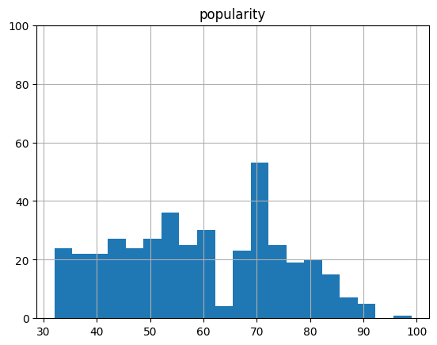

```python
not_tversion.hist(column = 'popularity', bins = 20)
plt.ylim(0, 100)
```

Difference:

In the first histogram, there is a prominent peak around the 60-70 popularity score range.

In the second histogram, the peak in the 60-70 range is less pronounced.

The exclusion of "Taylor's Version" songs appears to have removed a portion of songs with high popularity scores.

### part (b) TODO

```python
ts_bytime = ts_spotify.sort_values(by='release_date', ascending = True)
```

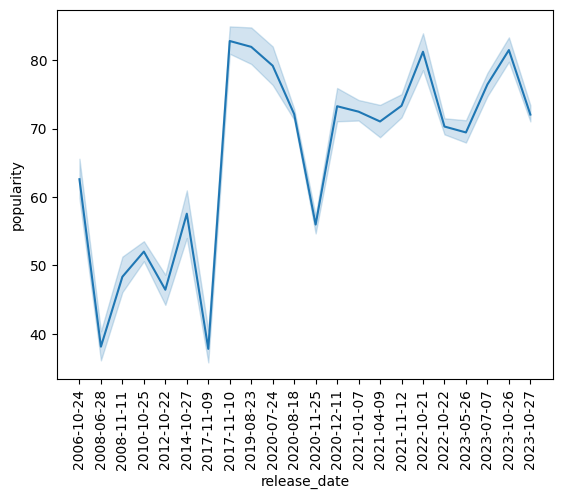

```python
sns.lineplot(data=ts_bytime, x='release_date', y='popularity')
_ = plt.xticks(rotation=90)
plt.show()
```

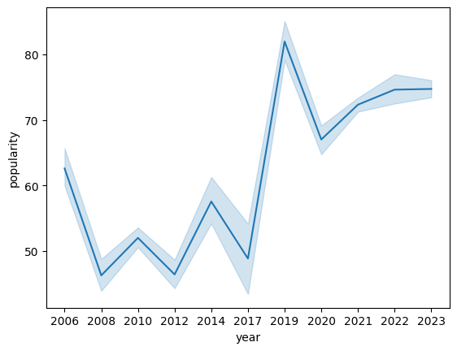

```python
ts_spotify['year'] = ts_spotify['release_date'].str.extract(r'(\d{4})')
# show the variation of the popularity of the songs over the years, ordered by the year in ascending order
sns.lineplot(x='year', y='popularity', data=ts_spotify.sort_values('year'))
```

This graph shows how song popularity fluctuates over time, with the biggest change occurring in 2017. Before 2017, popularity was mostly below 60. After 2017, popularity was mostly above 60.

# Q2:

- Report the average track duration for each album.
- Your answer should be in mm:ss (minutes:seconds) format rather than the milliseconds that are reported in the original dataset. (10)

Report the average track duration for each album.

```python
# ts_spotify.pivot_table(index = 'album', values=['duration_ms', 'name'], aggfunc={'duration_ms': 'mean', 'name': 'count'}).sort_values('duration_ms', ascending = False)
```

```python
d = ts_spotify.pivot_table(index = 'album', values='duration_ms', aggfunc='mean').sort_values('duration_ms', ascending = False)
d['duration_ms'] = pd.to_datetime(d['duration_ms'], unit='ms').dt.strftime('%M:%S')
d
```

| album | duration_ms |
| --- | --- |
| Speak Now World Tour Live | 04:57 |
| Speak Now | 04:47 |
| Speak Now (Taylor's Version) | 04:45 |
| Speak Now (Deluxe Edition) | 04:35 |
| Red (Taylor's Version) | 04:21 |
| Fearless Platinum Edition | 04:10 |
| Fearless | 04:07 |
| Red (Deluxe Edition) | 04:06 |
| Fearless (Taylor's Version) | 04:05 |
| evermore (deluxe version) | 04:03 |
| Red | 04:03 |
| evermore | 04:03 |
| reputation Stadium Tour Surprise Song Playlist | 04:02 |
| folklore | 03:58 |
| folklore: the long pond studio sessions (from the Disney+ special) [deluxe edition] | 03:57 |
| folklore (deluxe version) | 03:56 |
| 1989 | 03:45 |
| reputation | 03:43 |
| 1989 (Taylor's Version) | 03:42 |
| 1989 (Taylor's Version) [Deluxe] | 03:41 |
| 1989 (Deluxe Edition) | 03:37 |
| Taylor Swift | 03:33 |
| Midnights (The Til Dawn Edition) | 03:30 |
| Live From Clear Channel Stripped 2008 | 03:29 |
| Midnights (3am Edition) | 03:28 |
| Lover | 03:26 |
| Midnights | 03:23 |

# Q3:

- Generate correlation heatmaps to visualize the relationships between song features, utilizing a diverging color map with white representing a zero correlation.
- Identify the top five strongest correlations among these features.
- Provide an analysis of your findings, including explanations for why certain variables exhibit strong correlations and the potential rationale behind these relationships.

### part(a)

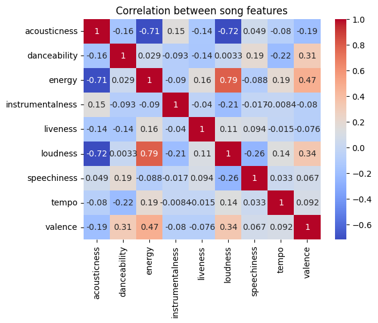

```python
song_features = ['acousticness', 'danceability', 'energy', 'instrumentalness', 'liveness', 'loudness', 'speechiness', 'tempo', 'valence']
features_corr = ts_spotify[song_features].corr()

sns.heatmap(features_corr, cmap="coolwarm", annot = True)
plt.title('Correlation between song features')
```

### part(b)

```python
corr = features_corr.stack().to_frame().reset_index()
corr = corr.sort_values(by=0,key=lambda col:abs(col),ascending=False)
corr = corr.rename(columns={'level_0':'var1','level_1':'var2',0:'corr'})
corr = corr.drop(corr[corr['var1'] == corr['var2']].index)
corr = corr.drop_duplicates('corr')
corr.head(5)
```

|  | var1 | var2 | corr |
| --- | --- | --- | --- |
| 47 | loudness | energy | 0.788294 |
| 45 | loudness | acousticness | -0.717599 |
| 2 | acousticness | energy | -0.709822 |
| 74 | valence | energy | 0.474844 |
| 53 | loudness | valence | 0.338557 |

### part(c)

From part(b), we observed that "loudness" has highest positive correlation with "energy", also, "loudness" has high negetive correlation with "acousticness", therefore, there is potential relation between "energy" and "acousticness" (negetive correlation). From part(b), this potential relation get proved.

# Q4:

- Analyze how the position of the track on the album (i.e., track number) influences the song's popularity, considering additional musical features.
- Specifically, evaluate the correlation between track number and popularity, and then examine if certain musical features (e.g., danceability, energy, acousticness) mediate this relationship.
- Use both visual and statistical evidence to support your findings.
- Discuss how these features may interact with track position to affect a song's popularity (10)

```python
import statsmodels.api as sm
import statsmodels.formula.api as smf
```

```python
ts_spotify.head()
```

|  | Unnamed: 0 | name | album | release_date | track_number | id | uri | acousticness | danceability | energy | instrumentalness | liveness | loudness | speechiness | tempo | valence | popularity | duration_ms | year |
| --- | --- | --- | --- | --- | --- | --- | --- | --- | --- | --- | --- | --- | --- | --- | --- | --- | --- | --- | --- |
| 0 | 0 | Welcome To New York (Taylor's Version) | 1989 (Taylor's Version) [Deluxe] | 2023-10-27 | 1 | 4WUepByoeqcedHoYhSNHRt | spotify:track:4WUepByoeqcedHoYhSNHRt | 0.009420 | 0.757 | 0.610 | 0.000037 | 0.3670 | -4.840 | 0.0327 | 116.998 | 0.685 | 71 | 212600 | 2023 |
| 1 | 1 | Blank Space (Taylor's Version) | 1989 (Taylor's Version) [Deluxe] | 2023-10-27 | 2 | 0108kcWLnn2HlH2kedi1gn | spotify:track:0108kcWLnn2HlH2kedi1gn | 0.088500 | 0.733 | 0.733 | 0.000000 | 0.1680 | -5.376 | 0.0670 | 96.057 | 0.701 | 72 | 231833 | 2023 |
| 2 | 2 | Style (Taylor's Version) | 1989 (Taylor's Version) [Deluxe] | 2023-10-27 | 3 | 3Vpk1hfMAQme8VJ0SNRSkd | spotify:track:3Vpk1hfMAQme8VJ0SNRSkd | 0.000421 | 0.511 | 0.822 | 0.019700 | 0.0899 | -4.785 | 0.0397 | 94.868 | 0.305 | 74 | 231000 | 2023 |
| 3 | 3 | Out Of The Woods (Taylor's Version) | 1989 (Taylor's Version) [Deluxe] | 2023-10-27 | 4 | 1OcSfkeCg9hRC2sFKB4IMJ | spotify:track:1OcSfkeCg9hRC2sFKB4IMJ | 0.000537 | 0.545 | 0.885 | 0.000056 | 0.3850 | -5.968 | 0.0447 | 92.021 | 0.206 | 72 | 235800 | 2023 |
| 4 | 4 | All You Had To Do Was Stay (Taylor's Version) | 1989 (Taylor's Version) [Deluxe] | 2023-10-27 | 5 | 2k0ZEeAqzvYMcx9Qt5aClQ | spotify:track:2k0ZEeAqzvYMcx9Qt5aClQ | 0.000656 | 0.588 | 0.721 | 0.000000 | 0.1310 | -5.579 | 0.0317 | 96.997 | 0.520 | 71 | 193289 | 2023 |

### part(a)

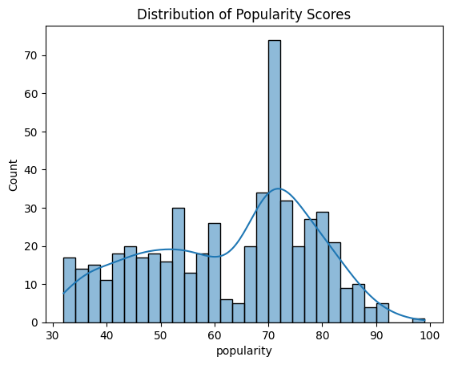

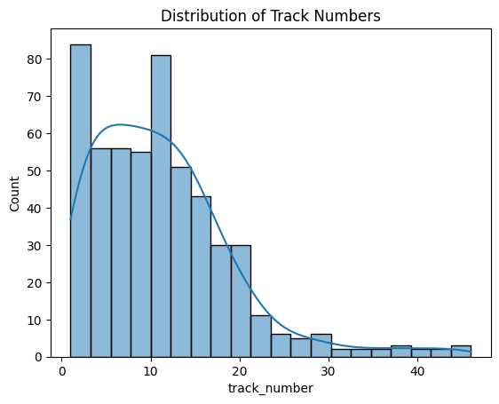

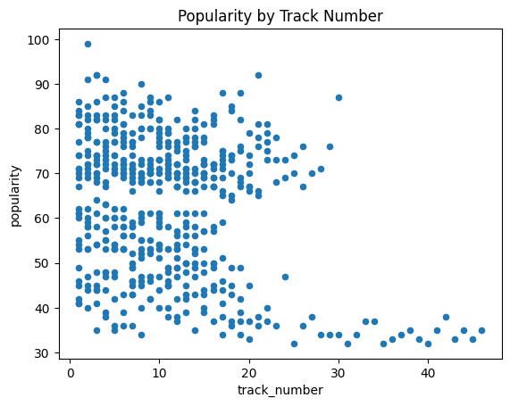

```python
sns.histplot(ts_spotify['popularity'], bins=30, kde=True)
plt.title('Distribution of Popularity Scores')
plt.show()

sns.histplot(ts_spotify['track_number'], bins=20, kde=True)
plt.title('Distribution of Track Numbers')
plt.show()

ts_spotify.plot.scatter(x='track_number', y='popularity')
plt.title('Popularity by Track Number')
```

It seems like there is relationship between track_number and popularity, as the track number increases, the popularity appears to decline.

correlation between track number and popularity:

```python
correlation = ts_spotify[['track_number', 'popularity']].corr()
correlation
```

|  | track_number | popularity |
| --- | --- | --- |
| track_number | 1.000000 | -0.276381 |
| popularity | -0.276381 | 1.000000 |

### Explore Influence of Other Musical Features

```python
correlarion1 = ts_spotify[song_features + ['popularity'] + ['track_number']].corr()
correlarion1
```

|  | acousticness | danceability | energy | instrumentalness | liveness | loudness | speechiness | tempo | valence | popularity | track_number |
| --- | --- | --- | --- | --- | --- | --- | --- | --- | --- | --- | --- |
| acousticness | 1.000000 | -0.164865 | -0.709822 | 0.150512 | -0.135063 | -0.717599 | 0.049464 | -0.080055 | -0.194686 | 0.076134 | 0.005514 |
| danceability | -0.164865 | 1.000000 | 0.029458 | -0.092990 | -0.143591 | 0.003267 | 0.192788 | -0.219289 | 0.312468 | 0.059702 | -0.034588 |
| energy | -0.709822 | 0.029458 | 1.000000 | -0.090230 | 0.156221 | 0.788294 | -0.087605 | 0.188427 | 0.474844 | -0.086805 | -0.000274 |
| instrumentalness | 0.150512 | -0.092990 | -0.090230 | 1.000000 | -0.039979 | -0.208814 | -0.017342 | -0.008387 | -0.079922 | 0.055110 | -0.033178 |
| liveness | -0.135063 | -0.143591 | 0.156221 | -0.039979 | 1.000000 | 0.112448 | 0.094134 | -0.015203 | -0.075754 | -0.160575 | -0.051937 |
| loudness | -0.717599 | 0.003267 | 0.788294 | -0.208814 | 0.112448 | 1.000000 | -0.261008 | 0.140450 | 0.338557 | -0.187421 | -0.024528 |
| speechiness | 0.049464 | 0.192788 | -0.087605 | -0.017342 | 0.094134 | -0.261008 | 1.000000 | 0.033108 | 0.066943 | 0.052525 | 0.004819 |
| tempo | -0.080055 | -0.219289 | 0.188427 | -0.008387 | -0.015203 | 0.140450 | 0.033108 | 1.000000 | 0.092255 | -0.015050 | 0.051063 |
| valence | -0.194686 | 0.312468 | 0.474844 | -0.079922 | -0.075754 | 0.338557 | 0.066943 | 0.092255 | 1.000000 | -0.077181 | -0.010421 |
| popularity | 0.076134 | 0.059702 | -0.086805 | 0.055110 | -0.160575 | -0.187421 | 0.052525 | -0.015050 | -0.077181 | 1.000000 | -0.276381 |
| track_number | 0.005514 | -0.034588 | -0.000274 | -0.033178 | -0.051937 | -0.024528 | 0.004819 | 0.051063 | -0.010421 | -0.276381 | 1.000000 |

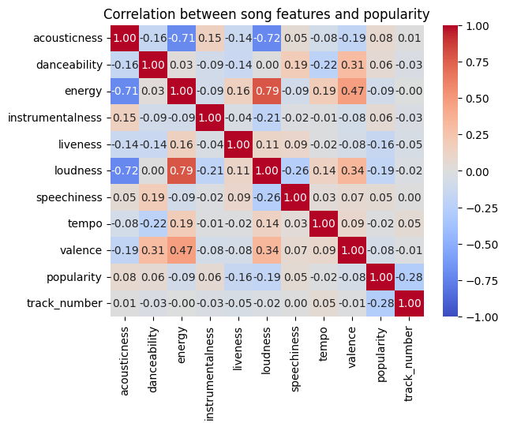

```python
sns.heatmap(correlarion1, cmap="coolwarm", vmax=1,vmin=-1,annot=True, fmt=".2f" )
plt.title('Correlation between song features and popularity')
```

Use heatmap, we can oberserved that track_number have relationship with popularity, and liveness and loudness may mediate this relationship.

```python
# use OLS to fit a linear model to predict popularity based on track number
model = smf.ols('popularity ~ track_number', data=ts_spotify).fit()
model.summary()
```

OLS Regression Results

| Dep. Variable: | popularity | R-squared: | 0.076 |
| --- | --- | --- | --- |
| Model: | OLS | Adj. R-squared: | 0.075 |
| Method: | Least Squares | F-statistic: | 43.67 |
| Date: | Tue, 20 Feb 2024 | Prob (F-statistic): | 9.53e-11 |
| Time: | 21:31:12 | Log-Likelihood: | -2175.5 |
| No. Observations: | 530 | AIC: | 4355. |
| Df Residuals: | 528 | BIC: | 4364. |
| Df Model: | 1 |  |  |
| Covariance Type: | nonrobust |  |  |

|  | coef | std err | t | P>\|t\| | [0.025 | 0.975] |
| --- | --- | --- | --- | --- | --- | --- |
| Intercept | 68.6838 | 1.100 | 62.452 | 0.000 | 66.523 | 70.844 |
| track_number | -0.5291 | 0.080 | -6.608 | 0.000 | -0.686 | -0.372 |

| Omnibus: | 147.123 | Durbin-Watson: | 0.277 |
| --- | --- | --- | --- |
| Prob(Omnibus): | 0.000 | Jarque-Bera (JB): | 27.164 |
| Skew: | -0.165 | Prob(JB): | 1.26e-06 |
| Kurtosis: | 1.941 | Cond. No. | 23.7 |

Notes:  
[1] Standard Errors assume that the covariance matrix of the errors is correctly specified.

```python
# use OLS to fit a linear model to predict popularity based on other song features
model0 = smf.ols('popularity ~ track_number + liveness + loudness', data=ts_spotify).fit()
model0.summary()
```

OLS Regression Results

| Dep. Variable: | popularity | R-squared: | 0.138 |
| --- | --- | --- | --- |
| Model: | OLS | Adj. R-squared: | 0.133 |
| Method: | Least Squares | F-statistic: | 28.07 |
| Date: | Tue, 20 Feb 2024 | Prob (F-statistic): | 7.54e-17 |
| Time: | 21:31:12 | Log-Likelihood: | -2157.2 |
| No. Observations: | 530 | AIC: | 4322. |
| Df Residuals: | 526 | BIC: | 4339. |
| Df Model: | 3 |  |  |
| Covariance Type: | nonrobust |  |  |

|  | coef | std err | t | P>\|t\| | [0.025 | 0.975] |
| --- | --- | --- | --- | --- | --- | --- |
| Intercept | 64.7773 | 2.107 | 30.745 | 0.000 | 60.638 | 68.916 |
| track_number | -0.5529 | 0.078 | -7.123 | 0.000 | -0.705 | -0.400 |
| liveness | -16.7185 | 4.381 | -3.816 | 0.000 | -25.324 | -8.113 |
| loudness | -0.9201 | 0.212 | -4.344 | 0.000 | -1.336 | -0.504 |

| Omnibus: | 50.601 | Durbin-Watson: | 0.396 |
| --- | --- | --- | --- |
| Prob(Omnibus): | 0.000 | Jarque-Bera (JB): | 16.994 |
| Skew: | -0.132 | Prob(JB): | 0.000204 |
| Kurtosis: | 2.163 | Cond. No. | 111. |

Notes:  
[1] Standard Errors assume that the covariance matrix of the errors is correctly specified.

from upper statistic analysis, we can see the liveness and loudness also significant in this model. Also, we can see that the R^2 increase from 0.076 with model(popularity ~ track_number) to 0.138 with model0(popularity ~ track_number + liveness + loudness), which indicating the model interpretation improves.

```python
# influnce points
# fig, ax = plt.subplots(figsize=(12,8))
# fig = sm.graphics.influence_plot(model0, ax= ax, criterion="cooks",alpha=.05)
```

# Q5:

- Explore the characteristics that differentiate popular songs from less popular ones.
- Divide the songs into popular (popularity rating of 60 or higher) and less popular (popularity rating of less than 60).
- Conduct a comparative analysis of these two groups across multiple features: danceability, energy, acousticness, and tempo.
- Use ANOVA tests to determine if differences in these features between popular and less popular songs are statistically significant.
- Additionally, explore if there's a notable trend in the duration of songs (duration_ms) between the two groups. (15)

Divide the songs into popular and less popular

```python
# Create a new column called 'popular' that is 1 if the popularity is greater than 60 and 0 otherwise
ts_spotify['popular'] = ts_spotify['popularity'].apply(lambda x: 1 if x > 60 else 0)
```

Show the popularity and difference between popular and less popular group

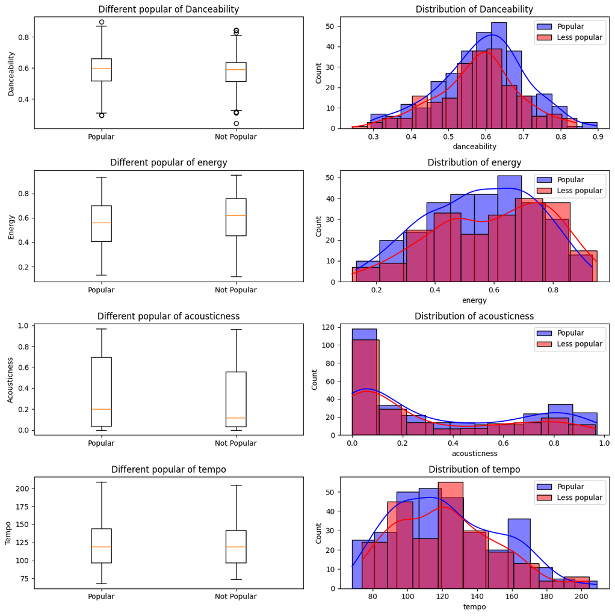

```python
plt.figure(figsize=(12, 12))
plt.subplot(4, 2, 1)
plt.boxplot([ts_spotify[ts_spotify['popular'] == 1]['danceability'], ts_spotify[ts_spotify['popular'] == 0]['danceability']], labels=['Popular', 'Not Popular'], )
plt.ylabel('Danceability')
plt.title('Different popular of Danceability')
plt.subplot(4, 2, 2)
sns.histplot(ts_spotify[ts_spotify['popular'] == 1]['danceability'], kde=True,  color='blue', label='Popular')
sns.histplot(ts_spotify[ts_spotify['popular'] == 0]['danceability'], kde=True,  color='red', label='Less popular')
plt.title('Distribution of Danceability')
plt.legend()
plt.subplot(4, 2, 3)
plt.boxplot([ts_spotify[ts_spotify['popular'] == 1]['energy'], ts_spotify[ts_spotify['popular'] == 0]['energy']], labels=['Popular', 'Not Popular'])
plt.title('Different popular of energy')
plt.ylabel('Energy')
plt.subplot(4, 2, 4)
sns.histplot(ts_spotify[ts_spotify['popular'] == 1]['energy'], kde=True,  color='blue', label='Popular')
sns.histplot(ts_spotify[ts_spotify['popular'] == 0]['energy'], kde=True,  color='red', label='Less popular')
plt.title('Distribution of energy')
plt.legend()
plt.subplot(4, 2, 5)
plt.boxplot([ts_spotify[ts_spotify['popular'] == 1]['acousticness'], ts_spotify[ts_spotify['popular'] == 0]['acousticness']], labels=['Popular', 'Not Popular'])
plt.title('Different popular of acousticness')
plt.ylabel('Acousticness')
plt.subplot(4, 2, 6)
sns.histplot(ts_spotify[ts_spotify['popular'] == 1]['acousticness'], kde=True,  color='blue', label='Popular')
sns.histplot(ts_spotify[ts_spotify['popular'] == 0]['acousticness'], kde=True,  color='red', label='Less popular')
plt.title('Distribution of acousticness')
plt.legend()
plt.subplot(4, 2, 7)
plt.boxplot([ts_spotify[ts_spotify['popular'] == 1]['tempo'], ts_spotify[ts_spotify['popular'] == 0]['tempo']], labels=['Popular', 'Not Popular'])
plt.title('Different popular of tempo')
plt.ylabel('Tempo')
plt.subplot(4, 2, 8)
sns.histplot(ts_spotify[ts_spotify['popular'] == 1]['tempo'], kde=True,  color='blue', label='Popular')
sns.histplot(ts_spotify[ts_spotify['popular'] == 0]['tempo'], kde=True,  color='red', label='Less popular')
plt.title('Distribution of tempo')
plt.legend()
plt.tight_layout()
plt.show()
```

Do ANOVA test

```python
from statsmodels.formula.api import ols
```

```python
danceability_lm = ols('popular ~ danceability', data=ts_spotify).fit()
table = sm.stats.anova_lm(danceability_lm, typ=2)
table
# no difference for the danceability between popular and not popular songs
```

|  | sum_sq | df | F | PR(>F) |
| --- | --- | --- | --- | --- |
| danceability | 0.499732 | 1.0 | 2.053188 | 0.15248 |
| Residual | 128.511589 | 528.0 | NaN | NaN |

From the analysis, there is no difference for the danceability between popular and not popular songs

```python
energy_lm = ols('popular ~ energy', data=ts_spotify).fit()
table = sm.stats.anova_lm(energy_lm, typ=2)
table
# there is difference for the energy between popular and not popular songs
```

|  | sum_sq | df | F | PR(>F) |
| --- | --- | --- | --- | --- |
| energy | 1.464898 | 1.0 | 6.064191 | 0.014113 |
| Residual | 127.546423 | 528.0 | NaN | NaN |

From the analysis, there is difference for the energy between popular and not popular songs

```python
acousticness_lm = ols('popular ~ acousticness', data=ts_spotify).fit()
table = sm.stats.anova_lm(acousticness_lm, typ=2)
table
# there is difference for the energy between popular and not popular songs
```

|  | sum_sq | df | F | PR(>F) |
| --- | --- | --- | --- | --- |
| acousticness | 1.134588 | 1.0 | 4.684686 | 0.03088 |
| Residual | 127.876733 | 528.0 | NaN | NaN |

From the analysis, there is difference for the acousticness between popular and not popular songs

```python
tempo_lm = ols('popular ~ tempo', data=ts_spotify).fit()
table = sm.stats.anova_lm(tempo_lm, typ=2)
table
# no difference for the energy between popular and not popular songs
```

|  | sum_sq | df | F | PR(>F) |
| --- | --- | --- | --- | --- |
| tempo | 0.000777 | 1.0 | 0.00318 | 0.95505 |
| Residual | 129.010544 | 528.0 | NaN | NaN |

From the analysis, there is no difference for the tempo between popular and not popular songs

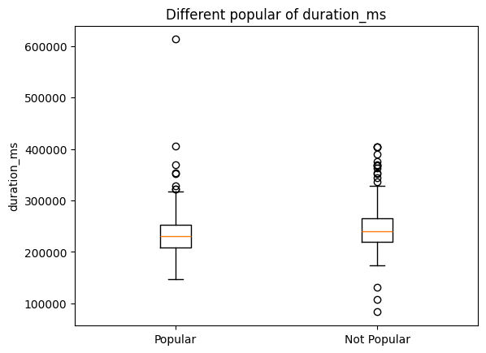

```python
plt.boxplot([ts_spotify[ts_spotify['popular'] == 1]['duration_ms'], ts_spotify[ts_spotify['popular'] == 0]['duration_ms']], labels=['Popular', 'Not Popular'])
plt.title('Different popular of duration_ms')
plt.ylabel('duration_ms')
```

```python
time_lm = ols('duration_ms ~ popular', data=ts_spotify).fit()
table = sm.stats.anova_lm(time_lm, typ=2)
table
```

|  | sum_sq | df | F | PR(>F) |
| --- | --- | --- | --- | --- |
| popular | 2.514917e+10 | 1.0 | 12.070925 | 0.000554 |
| Residual | 1.100062e+12 | 528.0 | NaN | NaN |

By the ANOVA analysis, the p-value less than 0.05, so there is difference between two groups. Therefore, there is trend.

# Q6:

- Build a multiple linear regression model to predict the popularity of a song based on a set of acoustic features: 'liveness', 'danceability', 'energy', and 'acousticness'. Evaluate the model by reporting:
  - The coefficient of determination (i.e. $r^2$) for the entire model to understand how well these variables together predict song popularity.
  - The statistical significance of the regression model and each predictor variable within it.
  - Predictions for song popularity at two different levels of 'liveness': 0.22 and 0.50, while holding other variables at their mean values." (20)

```python
model1 = smf.ols('popularity ~  acousticness + danceability + energy +  liveness', data=ts_spotify).fit()
model1.summary()
```

OLS Regression Results

| Dep. Variable: | popularity | R-squared: | 0.032 |
| --- | --- | --- | --- |
| Model: | OLS | Adj. R-squared: | 0.025 |
| Method: | Least Squares | F-statistic: | 4.328 |
| Date: | Tue, 20 Feb 2024 | Prob (F-statistic): | 0.00188 |
| Time: | 21:31:13 | Log-Likelihood: | -2188.0 |
| No. Observations: | 530 | AIC: | 4386. |
| Df Residuals: | 525 | BIC: | 4407. |
| Df Model: | 4 |  |  |
| Covariance Type: | nonrobust |  |  |

|  | coef | std err | t | P>\|t\| | [0.025 | 0.975] |
| --- | --- | --- | --- | --- | --- | --- |
| Intercept | 62.9373 | 5.500 | 11.442 | 0.000 | 52.132 | 73.743 |
| acousticness | 1.6693 | 2.916 | 0.572 | 0.567 | -4.059 | 7.398 |
| danceability | 6.2513 | 6.006 | 1.041 | 0.298 | -5.547 | 18.049 |
| energy | -3.2302 | 4.912 | -0.658 | 0.511 | -12.880 | 6.420 |
| liveness | -15.3336 | 4.733 | -3.239 | 0.001 | -24.632 | -6.035 |

| Omnibus: | 57.039 | Durbin-Watson: | 0.299 |
| --- | --- | --- | --- |
| Prob(Omnibus): | 0.000 | Jarque-Bera (JB): | 25.052 |
| Skew: | -0.334 | Prob(JB): | 3.63e-06 |
| Kurtosis: | 2.170 | Cond. No. | 16.9 |

Notes:  
[1] Standard Errors assume that the covariance matrix of the errors is correctly specified.

R^2 = 0.032, which means the model explains about 3.2% of the variance (which is pretty bad). The model is statistically significant(the p-value, called "Prob (F-statistic)" in the output, is less than 0.05). From estimates for the parameters of the model, only 'liveness' is statistically significant, while other variables are not significant. we can use the equation:

`Popularity = 62.94 + 1.67*acousticness + 6.25*danceability + (-3.23)*energy + (-15.33)*liveness`

```python
print('mean of acousticness is ', ts_spotify['acousticness'].mean())
print('mean of danceability is ', ts_spotify['danceability'].mean())
print('mean of energy is ', ts_spotify['energy'].mean())
```

```
mean of acousticness is  0.3192467245283019
mean of danceability is  0.5852849056603774
mean of energy is  0.5746094339622642
```

```python
liveness = [0.22, 0.5]
ppopularity = []
for i in range(len(liveness)):
    ppopularity = model1.params[0] + model1.params[1] * ts_spotify['acousticness'].mean() + model1.params[2] * ts_spotify['danceability'].mean() + model1.params[3] * ts_spotify['energy'].mean() + model1.params[4] * liveness[i]
    print('predicted popularity for liveness = ', liveness[i], ' is ', ppopularity)
```

```
predicted popularity for liveness =  0.22  is  61.89956760574776
predicted popularity for liveness =  0.5  is  57.60617285839033
```

By the upper model, and use mean of unkown parameter, predicted popularity for liveness = 0.22 is 61.9, predicted popularity for liveness = 0.5 is 57.6

# Q7:

- In addition to analyzing the popularity scores of original vs. re-recorded songs by Taylor Swift, evaluate the differences in their musical characteristics, including danceability, energy, acousticness, and duration_ms. Perform the following analyses:
  - a) Create visualizations that compare the distribution of popularity scores, as well as the mentioned acoustic features, between original and re-recorded songs.
  - b) Conduct statistical tests to determine if there are significant differences in popularity, danceability, energy, acousticness, and duration between the original and re-recorded songs. Report which versions are more favorable in terms of popularity and how the musical characteristics have changed in the re-recorded versions.
- hint: The re-recorded ones have `(Taylor’s version)` at the end of the album name. (20)

```python
ts_spotify.shape
```

```
(530, 20)
```

```python
pattern = r'Taylor\'s [Vv]ersion'
```

```python
ts_spotify.album.str.contains(pattern).value_counts()
```

```
album
False    409
True     121
Name: count, dtype: int64
```

```python
t = ts_spotify.album.str.contains(pattern)
re_recorded = ts_spotify[t]
re_recorded.shape
```

```
(121, 20)
```

```python
original  = ts_spotify[-t]
original.head()
```

|  | Unnamed: 0 | name | album | release_date | track_number | id | uri | acousticness | danceability | energy | instrumentalness | liveness | loudness | speechiness | tempo | valence | popularity | duration_ms | year | popular |
| --- | --- | --- | --- | --- | --- | --- | --- | --- | --- | --- | --- | --- | --- | --- | --- | --- | --- | --- | --- | --- |
| 65 | 65 | Lavender Haze | Midnights (The Til Dawn Edition) | 2023-05-26 | 1 | 24emu3sabKISjRkrys28jq | spotify:track:24emu3sabKISjRkrys28jq | 0.2360 | 0.735 | 0.454 | 0.001130 | 0.133 | -10.516 | 0.0876 | 97.043 | 0.0751 | 70 | 202395 | 2023 | 1 |
| 66 | 66 | Maroon | Midnights (The Til Dawn Edition) | 2023-05-26 | 2 | 6qxvy9Pe4RJIq5JBVbbwbS | spotify:track:6qxvy9Pe4RJIq5JBVbbwbS | 0.0609 | 0.650 | 0.397 | 0.000001 | 0.089 | -8.237 | 0.0365 | 108.055 | 0.0382 | 70 | 218270 | 2023 | 1 |
| 67 | 67 | Anti-Hero | Midnights (The Til Dawn Edition) | 2023-05-26 | 3 | 5qIHFdkW6phMsTZlN2g8Lc | spotify:track:5qIHFdkW6phMsTZlN2g8Lc | 0.1150 | 0.637 | 0.649 | 0.000001 | 0.147 | -6.590 | 0.0584 | 96.935 | 0.4970 | 69 | 200690 | 2023 | 1 |
| 68 | 68 | Snow On The Beach (feat. Lana Del Rey) | Midnights (The Til Dawn Edition) | 2023-05-26 | 4 | 7GA86Uo2jYbj8vIXe2nyWd | spotify:track:7GA86Uo2jYbj8vIXe2nyWd | 0.7050 | 0.653 | 0.331 | 0.001300 | 0.116 | -13.534 | 0.0390 | 110.014 | 0.1660 | 67 | 256124 | 2023 | 1 |
| 69 | 69 | You're On Your Own, Kid | Midnights (The Til Dawn Edition) | 2023-05-26 | 5 | 6PQOU00xWNrGwCZzboriXy | spotify:track:6PQOU00xWNrGwCZzboriXy | 0.4230 | 0.694 | 0.386 | 0.000010 | 0.126 | -10.312 | 0.0597 | 120.044 | 0.3900 | 70 | 194206 | 2023 | 1 |

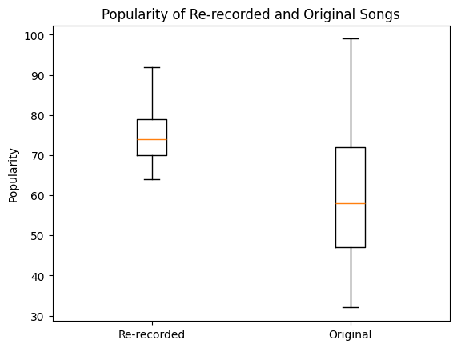

```python
plt.boxplot([re_recorded['popularity'], original['popularity']], labels=['Re-recorded', 'Original'])
plt.ylabel('Popularity')
plt.title('Popularity of Re-recorded and Original Songs')
```

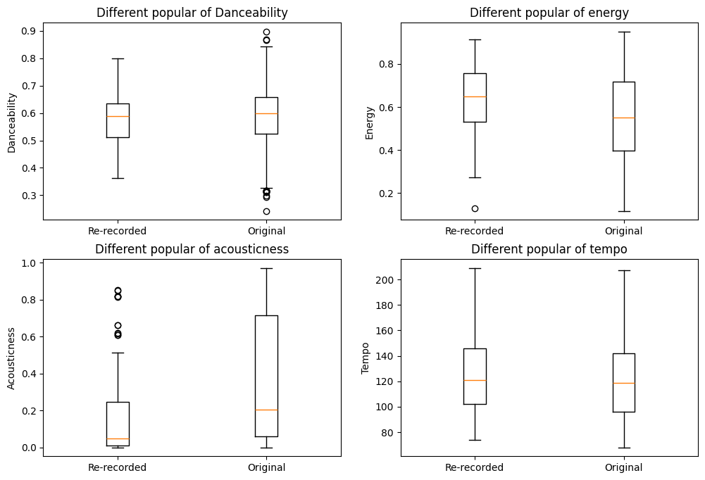

```python
plt.figure(figsize=(12, 8))
plt.subplot(2, 2, 1)
plt.boxplot([re_recorded['danceability'], original['danceability']], labels=['Re-recorded', 'Original'])
plt.title('Different popular of Danceability')
plt.ylabel('Danceability')
plt.subplot(2, 2, 2)
plt.boxplot([re_recorded['energy'], original['energy']], labels=['Re-recorded', 'Original'])
plt.title('Different popular of energy')
plt.ylabel('Energy')
plt.subplot(2, 2, 3)
plt.boxplot([re_recorded['acousticness'], original['acousticness']], labels=['Re-recorded', 'Original'])
plt.title('Different popular of acousticness')
plt.ylabel('Acousticness')
plt.subplot(2, 2, 4)
plt.boxplot([re_recorded['tempo'], original['tempo']], labels=['Re-recorded', 'Original'])
plt.title('Different popular of tempo')
plt.ylabel('Tempo')
```

```python
from scipy.stats import ttest_ind
```

```python
ttest_ind(re_recorded['popularity'],original["popularity"])
```

```
TtestResult(statistic=10.671747268594283, pvalue=3.300854876744513e-24, df=528.0)
```

For popularity: p-value < 0.05. The difference between the two groups is statistically significant. Re-records songs tends to be more popular(combined with boxplot anlysis).

```python
ttest_ind(re_recorded['danceability'],original["danceability"])
```

```
TtestResult(statistic=-0.13844374376141785, pvalue=0.8899425108339462, df=528.0)
```

```python
ttest_ind(re_recorded['energy'],original["energy"])
```

```
TtestResult(statistic=4.22498701562728, pvalue=2.8149894300821783e-05, df=528.0)
```

```python
ttest_ind(re_recorded['acousticness'],original["acousticness"])
```

```
TtestResult(statistic=-6.265729935008311, pvalue=7.707802752508449e-10, df=528.0)
```

```python
ttest_ind(re_recorded['duration_ms'],original["duration_ms"])
```

```
TtestResult(statistic=2.3329863111852873, pvalue=0.020023527254703802, df=528.0)
```

BONUS, worth up to 2 points: How would you determine whether [Taylor Swift has had an effect on the popularity of football](https://duckduckgo.com/?q=taylor+swift+football&atb=v314-1&ia=web)? What data would you need? What analysis would you perform? What would you expect the results to be?

DATA NEEDED:

Taylor Swift Career Timeline: From which football game Taylor Swift attended, alumb popularity with time, ect.

Football popularity with Timeline: The avg price tickets for each football games, the number of peopel attend for each of football game, the football game match TV ratings, the football game match television broadcast ratings, merchandise sales with football, ect.

ANALYSIS PERFOEMED

Correlation Analysis: Examining the timeline of Taylor Swift's football attend and how they relate to football trends.

Regression Analysis: If we observed a correlation, regression analysis would help quantify this relationship, and determine whether other factors may be influencing the observed trend.

T-test/ANOVA: Divide the data into two group: one is before Taylor attend any football game, the other is after Taylor attend the football game, compare with some charateristic difference use T-test/ANOVA

EXPECTED RESULT:

If Taylor Swift had a positive impact on the popularity of football, then the popularity of football games increased significantly following Taylor Swift's attend in football games: This could manifest as increased television ratings, an increase in the number of people purchasing tickets to football matches, an increase in ticket prices for football matches, an increase in social media activity, or an increase in merchandise sales that cannot be explained by other events or seasonal patterns.

### Submit your completed assignment in both IPYNB and HTML formats.